# AWS Rekogntion: What are some common traits in Expensive Houses and apartments in Beijing

## Section 1.Introduction

Importing packages

```python
import pandas as pd
import matplotlib.pyplot as plt
import seaborn as sns
import boto3
import s3fs
from PIL import Image
import numpy as np
```

To open images from S3 bucket we utilized the following code

```python
fs = s3fs.S3FileSystem()
```

```python
file = fs.open('s3://beijinghousingprice/Diagram.png')
```

We open the diagram on how we are going to use AWS service to solve our questions. First, we collected 9 pictures from Lianjia. Then, we uploaded them to the S3 bucket. By using AWS Rekogntion from AWS Lamda, we collected data from detecting the images and used seaborn and Matplotlib to generate some visualiation and analysis.

[figure not shown]

```python
image = Image.open(file)
display(image)
```

Collecting these 9 picture in the following link: [link] https://bj.fang.lianjia.com/loupan/bp1000ep9999/

[figure not shown]

```python
picture = fs.open('s3://beijinghousingprice/9picture.png')
image = Image.open(picture)
display(image)
```

## Section 2.AWS Service Preparation

After we uploaded all these 9 pictures to the S3 bucket, we utilized Rekogntion to detect the labels of these Beijing housing. We utilized rekognition service from boto3 and inputed all 9 pictures from our S3 buckets.

```python
rekognition=boto3.client('rekognition')
```

```python
House1 = rekognition.detect_labels(Image={'S3Object':{'Bucket':"beijing-houses-sampleimages",'Name':"beijing_1.jpg"}})
```

```python
House1['Labels']
```

```
[{'Name': 'Flagstone',
  'Confidence': 99.9316635131836,
  'Instances': [],
  'Parents': []},
 {'Name': 'Slate',
  'Confidence': 97.8118896484375,
  'Instances': [],
  'Parents': []},
 {'Name': 'Walkway',
  'Confidence': 97.6237564086914,
  'Instances': [],
  'Parents': [{'Name': 'Path'}]},
 {'Name': 'Path',
  'Confidence': 97.6237564086914,
  'Instances': [],
  'Parents': []},
 {'Name': 'Outdoors',
  'Confidence': 97.11878967285156,
  'Instances': [],
  'Parents': []},
 {'Name': 'Pavement',
  'Confidence': 83.25514221191406,
  'Instances': [],
  'Parents': [{'Name': 'Path'}]},
 {'Name': 'Sidewalk',
  'Confidence': 83.25514221191406,
  'Instances': [],
  'Parents': [{'Name': 'Path'}]},
 {'Name': 'Nature',
  'Confidence': 81.13565063476562,
  'Instances': [],
  'Parents': []},
 {'Name': 'Plant',
  'Confidence': 80.59845733642578,
  'Instances': [],
  'Parents': []},
 {'Name': 'Tree',
  'Confidence': 80.59845733642578,
  'Instances': [],
  'Parents': [{'Name': 'Plant'}]},
```

[output cut: 49 more lines]

```
  'Parents': [{'Name': 'Architecture'}, {'Name': 'Building'}]},
 {'Name': 'Spire',
  'Confidence': 56.08344650268555,
  'Instances': [],
  'Parents': [{'Name': 'Tower'},
   {'Name': 'Architecture'},
   {'Name': 'Building'}]},
 {'Name': 'Architecture',
  'Confidence': 56.08344650268555,
  'Instances': [],
  'Parents': [{'Name': 'Building'}]},
 {'Name': 'Downtown',
  'Confidence': 56.075225830078125,
  'Instances': [],
  'Parents': [{'Name': 'City'}, {'Name': 'Urban'}, {'Name': 'Building'}]}]
```

```python
House2 = rekognition.detect_labels(Image={'S3Object':{'Bucket':"beijing-houses-sampleimages",'Name':"beijing_2.jpg"}})
```

```python
House2['Labels']
```

```
[{'Name': 'Flooring',
  'Confidence': 99.79438781738281,
  'Instances': [],
  'Parents': []},
 {'Name': 'Floor',
  'Confidence': 99.5693359375,
  'Instances': [],
  'Parents': []},
 {'Name': 'Wood',
  'Confidence': 99.430419921875,
  'Instances': [],
  'Parents': []},
 {'Name': 'Hardwood',
  'Confidence': 97.88438415527344,
  'Instances': [],
  'Parents': [{'Name': 'Wood'}]},
 {'Name': 'Building',
  'Confidence': 92.85478973388672,
  'Instances': [],
  'Parents': []},
 {'Name': 'Housing',
  'Confidence': 83.14571380615234,
  'Instances': [],
  'Parents': [{'Name': 'Building'}]},
 {'Name': 'House',
  'Confidence': 82.31316375732422,
  'Instances': [],
  'Parents': [{'Name': 'Housing'}, {'Name': 'Building'}]},
 {'Name': 'Mansion',
  'Confidence': 82.31316375732422,
  'Instances': [],
  'Parents': [{'Name': 'House'}, {'Name': 'Housing'}, {'Name': 'Building'}]},
 {'Name': 'Rug',
  'Confidence': 81.51689147949219,
  'Instances': [{'BoundingBox': {'Width': 0.8408364653587341,
     'Height': 0.32720068097114563,
     'Left': 0.04480154439806938,
     'Top': 0.672024130821228},
    'Confidence': 81.51689147949219}],
  'Parents': []},
 {'Name': 'Hotel',
  'Confidence': 74.18223571777344,
  'Instances': [],
  'Parents': [{'Name': 'Building'}]},
 {'Name': 'Architecture',
  'Confidence': 72.17906188964844,
  'Instances': [],
  'Parents': [{'Name': 'Building'}]},
 {'Name': 'Banister',
  'Confidence': 68.06832885742188,
  'Instances': [],
  'Parents': []},
 {'Name': 'Handrail',
  'Confidence': 68.06832885742188,
  'Instances': [],
  'Parents': []}]
```

```python
House3 = rekognition.detect_labels(Image={'S3Object':{'Bucket':"beijing-houses-sampleimages",'Name':"beijing_3.jpg"}})
```

```python
House3['Labels']
```

```
[{'Name': 'Floor',
  'Confidence': 97.77000427246094,
  'Instances': [],
  'Parents': []},
 {'Name': 'Building',
  'Confidence': 97.73542785644531,
  'Instances': [],
  'Parents': []},
 {'Name': 'Architecture',
  'Confidence': 97.73542785644531,
  'Instances': [],
  'Parents': [{'Name': 'Building'}]},
 {'Name': 'Convention Center',
  'Confidence': 97.62435150146484,
  'Instances': [],
  'Parents': [{'Name': 'Architecture'}, {'Name': 'Building'}]},
 {'Name': 'Office Building',
  'Confidence': 95.06087493896484,
  'Instances': [],
  'Parents': [{'Name': 'Building'}]},
 {'Name': 'Flooring',
  'Confidence': 94.74307250976562,
  'Instances': [],
  'Parents': []},
 {'Name': 'Lighting',
  'Confidence': 84.47010803222656,
  'Instances': [],
  'Parents': []},
 {'Name': 'Porch',
  'Confidence': 71.50045013427734,
  'Instances': [],
  'Parents': []},
 {'Name': 'City',
  'Confidence': 69.61248016357422,
  'Instances': [],
  'Parents': [{'Name': 'Urban'}, {'Name': 'Building'}]},
 {'Name': 'Urban',
  'Confidence': 69.61248016357422,
  'Instances': [],
  'Parents': []},
```

[output cut: 17 more lines]

```
  'Confidence': 67.2418212890625,
  'Instances': [],
  'Parents': [{'Name': 'Housing'}, {'Name': 'Building'}]},
 {'Name': 'Pillar',
  'Confidence': 65.89073944091797,
  'Instances': [],
  'Parents': [{'Name': 'Architecture'}, {'Name': 'Building'}]},
 {'Name': 'Column',
  'Confidence': 65.89073944091797,
  'Instances': [],
  'Parents': [{'Name': 'Architecture'}, {'Name': 'Building'}]},
 {'Name': 'Downtown',
  'Confidence': 55.555877685546875,
  'Instances': [],
  'Parents': [{'Name': 'City'}, {'Name': 'Urban'}, {'Name': 'Building'}]}]
```

```python
House4 = rekognition.detect_labels(Image={'S3Object':{'Bucket':"beijing-houses-sampleimages",'Name':"Beijing_4.jpg"}})
```

```python
House4['Labels']
```

```
[{'Name': 'Housing',
  'Confidence': 99.20854949951172,
  'Instances': [],
  'Parents': [{'Name': 'Building'}]},
 {'Name': 'Building',
  'Confidence': 99.20854949951172,
  'Instances': [],
  'Parents': []},
 {'Name': 'Condo',
  'Confidence': 99.20854949951172,
  'Instances': [],
  'Parents': [{'Name': 'Housing'}, {'Name': 'Building'}]},
 {'Name': 'Office Building',
  'Confidence': 96.19595336914062,
  'Instances': [],
  'Parents': [{'Name': 'Building'}]},
 {'Name': 'Campus',
  'Confidence': 88.60552978515625,
  'Instances': [],
  'Parents': []},
 {'Name': 'Urban',
  'Confidence': 88.1651611328125,
  'Instances': [],
  'Parents': []},
 {'Name': 'College',
  'Confidence': 84.27914428710938,
  'Instances': [],
  'Parents': []},
 {'Name': 'Town',
  'Confidence': 80.97513580322266,
  'Instances': [],
  'Parents': [{'Name': 'Urban'}, {'Name': 'Building'}]},
 {'Name': 'City',
  'Confidence': 80.97513580322266,
  'Instances': [],
  'Parents': [{'Name': 'Urban'}, {'Name': 'Building'}]},
 {'Name': 'Architecture',
  'Confidence': 60.64037322998047,
  'Instances': [],
  'Parents': [{'Name': 'Building'}]},
```

[output cut: 12 more lines]

```
 {'Name': 'High Rise',
  'Confidence': 57.857234954833984,
  'Instances': [],
  'Parents': [{'Name': 'City'}, {'Name': 'Urban'}, {'Name': 'Building'}]},
 {'Name': 'Apartment Building',
  'Confidence': 57.21671676635742,
  'Instances': [],
  'Parents': [{'Name': 'High Rise'},
   {'Name': 'City'},
   {'Name': 'Urban'},
   {'Name': 'Building'}]},
 {'Name': 'Convention Center',
  'Confidence': 56.547855377197266,
  'Instances': [],
  'Parents': [{'Name': 'Architecture'}, {'Name': 'Building'}]}]
```

To see if such an approach would work, we will run 5 other huse pictures through rekognition. These other houses are of different types from the first 4 as the houses other than mansions fall under the housing market and can cost a lot as well

```python
House5 = rekognition.detect_labels(Image={'S3Object':{'Bucket':"beijing-houses",'Name':" 3.333 mil-1.jpg"}})
```

```python
House5 ['Labels']
```

```
[{'Name': 'Nature',
  'Confidence': 99.95801544189453,
  'Instances': [],
  'Parents': []},
 {'Name': 'Landscape',
  'Confidence': 99.95801544189453,
  'Instances': [],
  'Parents': [{'Name': 'Outdoors'}, {'Name': 'Nature'}]},
 {'Name': 'Outdoors',
  'Confidence': 99.95801544189453,
  'Instances': [],
  'Parents': []},
 {'Name': 'Scenery',
  'Confidence': 99.79534912109375,
  'Instances': [],
  'Parents': [{'Name': 'Outdoors'}, {'Name': 'Nature'}]},
 {'Name': 'Urban',
  'Confidence': 96.7453842163086,
  'Instances': [],
  'Parents': []},
 {'Name': 'Building',
  'Confidence': 96.6797103881836,
  'Instances': [],
  'Parents': []},
 {'Name': 'Town',
  'Confidence': 96.6797103881836,
  'Instances': [],
  'Parents': [{'Name': 'Urban'}, {'Name': 'Building'}]},
 {'Name': 'City',
  'Confidence': 96.6797103881836,
  'Instances': [],
  'Parents': [{'Name': 'Urban'}, {'Name': 'Building'}]},
 {'Name': 'High Rise',
  'Confidence': 96.6797103881836,
  'Instances': [],
  'Parents': [{'Name': 'City'}, {'Name': 'Urban'}, {'Name': 'Building'}]},
 {'Name': 'Aerial View',
  'Confidence': 93.20661926269531,
  'Instances': [],
  'Parents': [{'Name': 'Landscape'},
```

[output cut: 46 more lines]

```
 {'Name': 'Park',
  'Confidence': 62.93752670288086,
  'Instances': [],
  'Parents': [{'Name': 'Lawn'},
   {'Name': 'Outdoors'},
   {'Name': 'Grass'},
   {'Name': 'Plant'}]},
 {'Name': 'Road',
  'Confidence': 62.107704162597656,
  'Instances': [],
  'Parents': []},
 {'Name': 'Water',
  'Confidence': 57.89323425292969,
  'Instances': [],
  'Parents': []}]
```

```python
House6 = rekognition.detect_labels(Image={'S3Object':{'Bucket':"beijing-houses",'Name':"0.668 mil-1.jpg"}})
```

```python
House6['Labels']
```

```
[{'Name': 'City',
  'Confidence': 99.09098052978516,
  'Instances': [],
  'Parents': [{'Name': 'Urban'}, {'Name': 'Building'}]},
 {'Name': 'High Rise',
  'Confidence': 99.09098052978516,
  'Instances': [],
  'Parents': [{'Name': 'City'}, {'Name': 'Urban'}, {'Name': 'Building'}]},
 {'Name': 'Building',
  'Confidence': 99.09098052978516,
  'Instances': [],
  'Parents': []},
 {'Name': 'Urban',
  'Confidence': 99.09098052978516,
  'Instances': [],
  'Parents': []},
 {'Name': 'Town',
  'Confidence': 99.09098052978516,
  'Instances': [],
  'Parents': [{'Name': 'Urban'}, {'Name': 'Building'}]},
 {'Name': 'Person',
  'Confidence': 97.06917572021484,
  'Instances': [{'BoundingBox': {'Width': 0.02605520747601986,
     'Height': 0.10446929931640625,
     'Left': 0.1463579684495926,
     'Top': 0.7319085597991943},
    'Confidence': 97.06917572021484},
   {'BoundingBox': {'Width': 0.019755570217967033,
     'Height': 0.09732013195753098,
     'Left': 0.16369187831878662,
     'Top': 0.7389796376228333},
    'Confidence': 91.66202545166016}],
  'Parents': []},
 {'Name': 'Human',
  'Confidence': 97.06917572021484,
  'Instances': [],
  'Parents': []},
 {'Name': 'Water',
  'Confidence': 96.16228485107422,
  'Instances': [],
```

[output cut: 45 more lines]

```
  'Confidence': 68.85736846923828,
  'Instances': [],
  'Parents': [{'Name': 'Waterfront'}, {'Name': 'Water'}]},
 {'Name': 'Skyscraper',
  'Confidence': 57.526634216308594,
  'Instances': [],
  'Parents': [{'Name': 'High Rise'},
   {'Name': 'Architecture'},
   {'Name': 'City'},
   {'Name': 'Building'},
   {'Name': 'Urban'}]},
 {'Name': 'People',
  'Confidence': 55.665374755859375,
  'Instances': [],
  'Parents': [{'Name': 'Person'}]}]
```

```python
House7 = rekognition.detect_labels(Image={'S3Object':{'Bucket':"beijing-houses",'Name':"0.742 mil-1.jpg"}})
```

```python
House7['Labels']
```

```
[{'Name': 'Town',
  'Confidence': 99.17654418945312,
  'Instances': [],
  'Parents': [{'Name': 'Urban'}, {'Name': 'Building'}]},
 {'Name': 'Urban',
  'Confidence': 99.17654418945312,
  'Instances': [],
  'Parents': []},
 {'Name': 'City',
  'Confidence': 99.17654418945312,
  'Instances': [],
  'Parents': [{'Name': 'Urban'}, {'Name': 'Building'}]},
 {'Name': 'Building',
  'Confidence': 99.17654418945312,
  'Instances': [],
  'Parents': []},
 {'Name': 'High Rise',
  'Confidence': 98.20333862304688,
  'Instances': [],
  'Parents': [{'Name': 'City'}, {'Name': 'Urban'}, {'Name': 'Building'}]},
 {'Name': 'Water',
  'Confidence': 91.80640411376953,
  'Instances': [],
  'Parents': []},
 {'Name': 'Downtown',
  'Confidence': 91.16691589355469,
  'Instances': [],
  'Parents': [{'Name': 'City'}, {'Name': 'Urban'}, {'Name': 'Building'}]},
 {'Name': 'Metropolis',
  'Confidence': 89.17172241210938,
  'Instances': [],
  'Parents': [{'Name': 'City'}, {'Name': 'Urban'}, {'Name': 'Building'}]},
 {'Name': 'Outdoors',
  'Confidence': 87.16519927978516,
  'Instances': [],
  'Parents': []},
 {'Name': 'Architecture',
  'Confidence': 84.87091827392578,
  'Instances': [],
  'Parents': [{'Name': 'Building'}]},
```

[output cut: 16 more lines]

```
   {'Name': 'City'},
   {'Name': 'Urban'},
   {'Name': 'Building'}]},
 {'Name': 'Housing',
  'Confidence': 64.9547119140625,
  'Instances': [],
  'Parents': [{'Name': 'Building'}]},
 {'Name': 'Condo',
  'Confidence': 55.4162483215332,
  'Instances': [],
  'Parents': [{'Name': 'Housing'}, {'Name': 'Building'}]},
 {'Name': 'Landscape',
  'Confidence': 55.25675582885742,
  'Instances': [],
  'Parents': [{'Name': 'Outdoors'}, {'Name': 'Nature'}]}]
```

```python
House8 = rekognition.detect_labels(Image={'S3Object':{'Bucket':"beijing-houses",'Name':"0.955 mil-1.jpg"}})
```

```python
House8 ['Labels']
```

```
[{'Name': 'High Rise',
  'Confidence': 99.75609588623047,
  'Instances': [],
  'Parents': [{'Name': 'City'}, {'Name': 'Urban'}, {'Name': 'Building'}]},
 {'Name': 'City',
  'Confidence': 99.75609588623047,
  'Instances': [],
  'Parents': [{'Name': 'Urban'}, {'Name': 'Building'}]},
 {'Name': 'Town',
  'Confidence': 99.75609588623047,
  'Instances': [],
  'Parents': [{'Name': 'Urban'}, {'Name': 'Building'}]},
 {'Name': 'Building',
  'Confidence': 99.75609588623047,
  'Instances': [],
  'Parents': []},
 {'Name': 'Urban',
  'Confidence': 99.75609588623047,
  'Instances': [],
  'Parents': []},
 {'Name': 'Office Building',
  'Confidence': 95.30611419677734,
  'Instances': [],
  'Parents': [{'Name': 'Building'}]},
 {'Name': 'Architecture',
  'Confidence': 92.0654067993164,
  'Instances': [],
  'Parents': [{'Name': 'Building'}]},
 {'Name': 'Skyscraper',
  'Confidence': 81.90796661376953,
  'Instances': [],
  'Parents': [{'Name': 'High Rise'},
   {'Name': 'Architecture'},
   {'Name': 'City'},
   {'Name': 'Building'},
   {'Name': 'Urban'}]},
 {'Name': 'Downtown',
  'Confidence': 77.28987884521484,
  'Instances': [],
  'Parents': [{'Name': 'City'}, {'Name': 'Urban'}, {'Name': 'Building'}]},
 {'Name': 'Apartment Building',
  'Confidence': 76.85713195800781,
  'Instances': [],
  'Parents': [{'Name': 'High Rise'},
   {'Name': 'City'},
   {'Name': 'Urban'},
   {'Name': 'Building'}]},
 {'Name': 'Road',
  'Confidence': 61.29502487182617,
  'Instances': [],
  'Parents': []}]
```

```python
House9 = rekognition.detect_labels(Image={'S3Object':{'Bucket':"beijing-houses",'Name':"0.985 mil-1.jpg"}})
```

```python
House9['Labels']
```

```
[{'Name': 'Building',
  'Confidence': 99.32666778564453,
  'Instances': [],
  'Parents': []},
 {'Name': 'Office Building',
  'Confidence': 99.32666778564453,
  'Instances': [],
  'Parents': [{'Name': 'Building'}]},
 {'Name': 'Condo',
  'Confidence': 94.335693359375,
  'Instances': [],
  'Parents': [{'Name': 'Housing'}, {'Name': 'Building'}]},
 {'Name': 'Housing',
  'Confidence': 94.335693359375,
  'Instances': [],
  'Parents': [{'Name': 'Building'}]},
 {'Name': 'Water',
  'Confidence': 88.77562713623047,
  'Instances': [],
  'Parents': []},
 {'Name': 'Outdoors',
  'Confidence': 80.37020111083984,
  'Instances': [],
  'Parents': []},
 {'Name': 'Architecture',
  'Confidence': 66.98990631103516,
  'Instances': [],
  'Parents': [{'Name': 'Building'}]},
 {'Name': 'Urban',
  'Confidence': 65.6782455444336,
  'Instances': [],
  'Parents': []},
 {'Name': 'Campus',
  'Confidence': 59.71380615234375,
  'Instances': [],
  'Parents': []},
 {'Name': 'Convention Center',
  'Confidence': 55.64946746826172,
  'Instances': [],
  'Parents': [{'Name': 'Architecture'}, {'Name': 'Building'}]}]
```

As interesting enough, we get enough data for the variables of architecture, Housing, Mansion, Downtowns to make analysis to answer the question: What are some common traits that might influence the beijing Housing prices?

## Section 3.Visualization and Analysis - What are some common traits that influence the Beijing Housing prices?

```
     Name    Price  ConfInterval
0  House1  2500000     56.083447
1  House2  3021312     72.179077
2  House3  2300423     97.735619
3  House4  3120193     60.640373
4  House6   668000     69.745819
5  House8   955000     84.870918
6  House9  3012312     66.989906
```

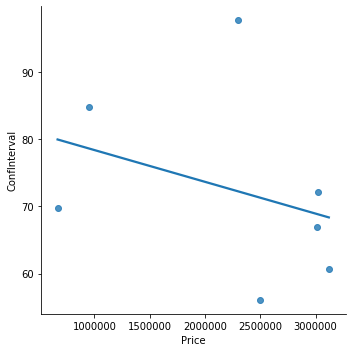

```python
Architecture = {
    'Name': ["House1", "House2", "House3", "House4","House6","House8","House9"],
    'Price': [2500000,3021312,2300423,3120193,668000,955000,3012312],
    'ConfInterval' :[56.0834465,72.17907715,97.73561859,60.64037323,69.74581909179688,84.87091827392578,66.98990631103516]
}
Architecturedf = pd.DataFrame (Architecture, columns = ['Name','Price','ConfInterval'])

print (Architecturedf)

sns.lmplot(x='Price', y='ConfInterval', data=Architecturedf, ci=None)
```

```
     Name    Price  ConfInterval
0  House1  2500000     83.199229
1  House2  3021312     83.145729
2  House3  2300423     67.243408
3  House4  3120193     99.208550
4  House5  2801231     81.998016
5  House7   742000     64.954712
6  House9   985000     94.335693
```

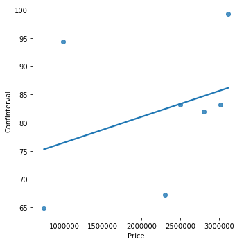

```python
Housing = {
    'Name': ["House1", "House2", "House3", "House4","House5","House7","House9"],
    'Price': [2500000,3021312,2300423,3120193,2801231,742000,985000],
    'ConfInterval' :[83.19922892,83.14572906,67.2434082,99.2085495,81.99801635742188,64.9547119140625,94.335693359375]
}
Housingdf = pd.DataFrame (Housing, columns = ['Name','Price','ConfInterval'])

print (Housingdf)
sns.lmplot(x='Price', y='ConfInterval', data=Housingdf, ci=None)
```

```
     Name    Price  ConfInterval
0  House1  2500000     82.921707
1  House2  3021312     82.313164
2  House3  2300423     67.243408
3  House4  3120193     99.208550
```

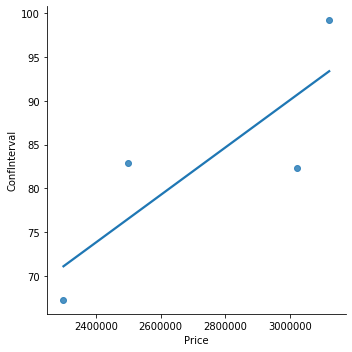

```python
Mansion = {
    'Name': ["House1", "House2", "House3", "House4"],
    'Price': [2500000,3021312,2300423,3120193],
    'ConfInterval' :[82.9217071533,82.31316376,67.2434082,99.2085495]
}
Mansiondf = pd.DataFrame (Mansion, columns = ['Name','Price','ConfInterval'])

print (Mansiondf)
sns.lmplot(x='Price', y='ConfInterval', data=Mansiondf, ci=None)
```

As seen, there are no labels which all 9 houses have in common. There are 2 (urban and Building) that 8/9 have in common; however, there are many labels which are not common to even 6 of the houses. As such, it might not be a good idea to see the trend by filling in the mean values for confidence intervals as this may skew the mean after all the values have been replaced. Another reason for this is that some labels are specific to houses such as waterfront. In this case, it would not make sense to have a mean confidence interval across the board as not every house is on the waterfront. An example of taking the mean value of the confidence interval for everyone and only using the images with the specified label is shown below. The label used here is downtown

```
     Name    Price  ConfInterval
0  House1  2500000     56.075218
1  House2  3021312     73.382325
2  House3  2300423     55.556019
3  House4  3120193     73.382325
4  House5  3333000     73.382325
5  House6   668000     86.823593
6  House7   742000     91.166916
7  House8   955000     77.289879
8  House9   985000     73.382325
```

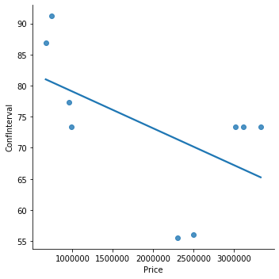

```python
Downtown = {
    'Name': ["House1", "House2", "House3", "House4","House5","House6","House7","House8","House9"],
    'Price': [2500000,3021312,2300423,3120193,3333000,668000,742000,955000,985000],
    'ConfInterval' :[56.0752182,73.38232498,55.55601883,73.38232498,73.38232498,86.82359314,91.16691589,77.28987885,73.38232498]
}
Downtowndf = pd.DataFrame (Downtown, columns = ['Name','Price','ConfInterval'])

print (Downtowndf)
sns.lmplot(x='Price', y='ConfInterval', data=Downtowndf, ci=None)
```

Another interesting label is the city label. 7/9 images have this label; however, all of these images should have the city label as all the houses are in Beijing, which is a city. It might be interesting to look at what images would be recognized as a city and what would not. We will discuss this feature in section 4 to check the authenticity of Downtown Label

### Conclusion on general metrics that affect the beijing housing price

As we did analysis and visualization using Seaborn and Matplotlib. We can see a postive effect of housing and Mansion label on the Beijing Housing price because Housing confidence level possibly determined by the size of the houses and mansion confidence level possibly determined by the delicate and decorative degree of the houses. We also see architecture and downtown label have a negative impact on the housing price. Downtown label can explained by not living closing to the center of Beijing. That definitely has a negative impact because citizens who lived away from the center may have less convenience in transportation. Architecture label, however, is a bit hard to explain. It might be because Beijing people did not like to live in a house that looks like the art or practice of designing and constructing buildings(according to definition on Architecture [link]https://www.lexico.com/definition/architecture). Living like an artist house is not convenient in life because you need to pay extra time to maintain the house, which did not fit into the quick living pace of average Beijing citizens.

## Section 4. Advanced Metric analysis - Are Housing label and Downtown label authentic?

As we analyzed above, Downtown label have a negative impact on the housing price and housing label have a positive impact on the housing price. Are they truly depicted by the AWS as the way we think? Did downtown label interpret a larger distance from Beijing city Center? Did a larger housing label interpret a larger housing size? In the following exercise, we will collect data from basic information provided by each house in Lianjia to chekc the authenticity of these labels.

### A .Downtown Label

By convension, Beijing citizens regard Dongcheng district as the representative city center. Thus, in our analysis, we will treat a remarkable place of interet in DongCheng District - Temple of heaven as the city center and measured each houses' distances to it.

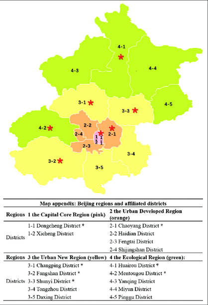

```python
picture = fs.open('s3://beijinghousingprice/Beijing_district.png')
image = Image.open(picture)
display(image)
```

Picture of Temple of Heaven

[figure not shown]

```python
picture = fs.open('s3://beijinghousingprice/tiantan.jpg')
image = Image.open(picture)
display(image)
```

By using Baidu map[link]https://map.baidu.com/ and addresses provided by Lianjia of each house, we can calculate the distance. Thus, we generated the following barplot and dataframe. Distance is in Kilometers

```python
Downtown1 = {
    'Name': ["House1", "House2", "House3", "House4","House5","House6","House7","House8","House9"],
    'Distance': [9.4,21.2,7.4,19.3,22.3,18.3,32.1,25.4,24.5],
    'ConfInterval' :[56.0752182,73.38232498,55.55601883,73.38232498,73.38232498,86.82359314,91.16691589,77.28987885,73.38232498]
}
```

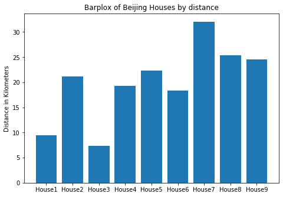

```python
fig = plt.figure()
Name = ["House1", "House2", "House3", "House4","House5","House6","House7","House8","House9"]
Distance = [9.4,21.2,7.4,19.3,22.3,18.3,32.1,25.4,24.5]
ax = fig.add_axes([0,0,1,1])
ax.bar(Name,Distance)
ax.set_ylabel('Distance in Kilometers')
ax.set_title('Barplox of Beijing Houses by distance')
plt.show()
```

Let's apply a simple linear regression model to check the relationship between confidence level of downtown and distance

```python
from scipy.stats import linregress
xs1 = [56.0752182,73.38232498,55.55601883,73.38232498,73.38232498,86.82359314,91.16691589,77.28987885,73.38232498]
ys1 = [9.4,21.2,7.4,19.3,22.3,18.3,32.1,25.4,24.5]
res1 = linregress(xs1, ys1)
res1
```

```
LinregressResult(slope=0.5502329813615174, intercept=-20.388486564707645, rvalue=0.8466740826298231, pvalue=0.00398669169606843, stderr=0.13070260570446787)
```

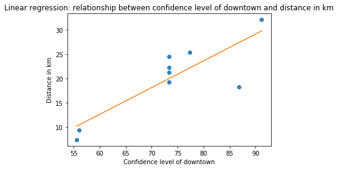

```python
plt.plot(xs1, ys1, 'o', alpha=0.9)
fx = np.array([min(xs1), max(xs1)])
fy = res1.intercept + res1.slope * fx
plt.plot(fx, fy, '-')
plt.xlabel('Confidence level of downtown')
plt.ylabel('Distance in km')
plt.title('Linear regression: relationship between confidence level of downtown and distance in km');
```

From the bar plot and the linear regression model we set up, we can conclude that confidence level of downtown have a positive relationship with the distance level. It has a positive slope of 0.55. Thus, our hypothesis is correct! If the houses is more far away from the city center pushing distance value up, that means the level of downtown will go up. AWS successfully captured the degree of downtown label for our houses!

### B. Housing label

As we supposed, housing size should have a postive relationship with the confidence level. By collecting all the 9 houses data on Lianjia, we generated the following dataset.

```python
Housing = {
    'Name': ["House1", "House2", "House3", "House4","House5","House7","House9"],
    'Size_m_square': [231, 219, 221, 285, 196, 162, 303],
    'ConfInterval' :[83.19922892,83.14572906,67.2434082,99.2085495,81.99801635742188,64.9547119140625,94.335693359375]
}
```

```python
subset = pd.DataFrame(Housing, columns = ['Size_m_square','ConfInterval'])
subset
```

|  | Size_m_square | ConfInterval |
| --- | --- | --- |
| 0 | 231 | 83.199229 |
| 1 | 219 | 83.145729 |
| 2 | 221 | 67.243408 |
| 3 | 285 | 99.208550 |
| 4 | 196 | 81.998016 |
| 5 | 162 | 64.954712 |
| 6 | 303 | 94.335693 |

Having a look of the correlation. It has a number of 0.84 which is positively correlated.

```python
subset.corr()
```

|  | Size_m_square | ConfInterval |
| --- | --- | --- |
| Size_m_square | 1.000000 | 0.843485 |
| ConfInterval | 0.843485 | 1.000000 |

```python
xs = subset['ConfInterval']
ys = subset['Size_m_square']
np.corrcoef(xs, ys)
```

[output not shown]

```python
res1 = linregress(xs, ys)
res1
```

```
LinregressResult(slope=3.259953113330243, intercept=-36.35589752625407, rvalue=0.8434848529986958, pvalue=0.017077472904013465, stderr=0.9284254505306828)
```

Generating a simple linear regression to check the degree of correlation

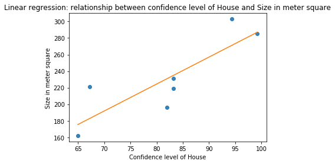

```python
plt.plot(xs, ys, 'o', alpha=0.9)
fx = np.array([min(xs), max(xs)])
fy = res1.intercept + res1.slope * fx
plt.plot(fx, fy, '-')
plt.xlabel('Confidence level of House')
plt.ylabel('Size in meter square')
plt.title('Linear regression: relationship between confidence level of House and Size in meter square');
```

Housing label did have a strong positive correlation between confidence level of House label and House size. It has a slope of 3.26. The regression model shows that when AWS detected a rising confidence level of house label, it means that size of corresponding house is larger!

## Section 5. Conclusion and Reference

Throughout the burst of Beijing Housing prices, some common traits did show up in these extremely expensive houses. Housing size and delicate degree of house have a positive relationship with the housing price. However, the location and artist degree of a house have a negative relationship with the housing price. In order to examine the ability of AWS to generate these confidence level, we measured the downtown confidence level and house confidence level corresponding to the distance from the city center and the actual housing size provided by Lianjia. They are showed a strong correlation. Thus, AWS successfully captured these traits.

Reference:

1. https://bj.fang.lianjia.com/loupan/bp1000ep9999/
2. https://en.wikipedia.org/wiki/Housing_in_China
3. https://en.wikipedia.org/wiki/Linear_regression#:~:text=In%20statistics%2C%20linear%20regression%20is,is%20called%20simple%20linear%20regression
4. https://colab.research.google.com/github/AllenDowney/ElementsOfDataScience/blob/master/10_regression.ipynb#scrollTo=IyFsb86MmBag
5. https://colab.research.google.com/github/AllenDowney/ElementsOfDataScience/blob/master/09_relationships.ipynb#scrollTo=tLfXOfMAmBVm
6. https://en.wikipedia.org/wiki/Temple_of_Heaven